# Social Status, Liberalization and Attitudes toward Redistribution

“Social Status, Liberalization and Attitudes toward Redistribution”

##### ISSP, Social Inequality, Cumulation (1987, 1992, 1999 & 2009)

##### ISSP, Environment, 1993, 2000 & 2010

$~$ $~$

#### **Nate Breznau, Lisa Heukamp & Hung H.V. Nguyen**

#### **University of Bremen**

$~$ $~$

Working paper available here: https://docs.google.com/document/d/1mST25rKYZ5wChRj5WyhxH_65RUa9MNR2OsO5B4-qcwY/edit#

Github repo: https://github.com/hungnguyen167/Social-Status

## Load Data

The data cleaning is done in the file “Social Status, Liberalization and Attitudes toward Redistribution.Rmd”

```r
load(paste0(wd,"socstat.Rda"))
```

# Descriptives

## Table 1. Cases by Country-Wave

```r
# Cross-tab years and countries
options(knitr.kable.NA = '')
tab1 <- df %>%
  dplyr::group_by(country, wave) %>%
  dplyr::summarize(n=n()) %>%
  spread(wave, n) %>%
  kable(., col.names = c("Country", "SI_1987", "SI_1992", "EN_1993", "SI_1999", "EN_2000", "SI_2009", "EN_2010"), caption = "Country Sample Size by Wave, ISSP 'Social Inequality (SI) & Environment (EN)", format.args = list(big.mark = ","))
kable_styling(tab1)
```

Country Sample Size by Wave, ISSP ’Social Inequality (SI) & Environment (EN)

| Country | SI_1987 | SI_1992 | EN_1993 | SI_1999 | EN_2000 | SI_2009 | EN_2010 |
| --- | --- | --- | --- | --- | --- | --- | --- |
| Argentina |  |  |  |  |  |  | 1,130 |
| Australia | 1,663 | 2,203 | 1,779 | 1,672 |  | 1,525 | 1,946 |
| Austria | 972 | 1,027 |  | 1,016 | 1,011 | 1,019 | 1,019 |
| Belgium |  |  |  |  |  |  | 1,142 |
| Bulgaria |  | 1,198 | 1,183 | 1,102 | 1,013 | 1,000 | 1,003 |
| Canada |  | 1,002 | 1,467 | 974 | 1,115 |  | 985 |
| Chile |  |  |  | 1,503 | 1,503 | 1,505 | 1,436 |
| Croatia |  |  |  |  |  |  | 1,210 |
| Cyprus |  |  |  | 1,000 |  | 1,000 |  |
| Czechia |  | 678 | 1,005 | 1,834 | 1,244 | 1,205 | 1,428 |
| Denmark |  |  |  | 1,823 | 1,069 |  | 1,305 |
| Finland |  |  |  |  | 1,528 |  | 1,211 |
| France |  |  |  | 1,889 |  | 2,817 | 2,253 |
| Germany | 1,397 | 3,391 | 2,106 | 1,432 | 1,501 | 1,395 | 1,407 |
| Hungary | 2,606 | 1,250 | 1,167 | 1,208 |  | 1,010 |  |
| Iceland |  |  |  |  |  |  | 798 |
| Ireland |  |  | 957 | 960 | 1,232 |  |  |
| Israel |  |  | 1,198 | 1,208 | 1,205 | 1,193 | 1,216 |
| Italy | 1,027 | 996 | 1,000 |  |  | 1,084 |  |
| Japan |  |  | 1,305 | 1,325 | 1,180 | 1,296 | 1,307 |
| Latvia |  |  |  | 1,100 | 1,000 | 1,069 | 1,000 |
| Lithuania |  |  |  |  |  |  | 1,023 |
| Mexico |  |  |  |  | 1,262 |  | 1,637 |
| Netherlands |  |  | 1,852 |  | 1,609 | 1,315 | 1,472 |
| New Zealand |  | 1,239 | 1,271 | 1,108 | 1,112 | 935 | 1,172 |
| Norway |  | 1,538 | 1,414 | 1,268 | 1,452 | 1,456 | 1,382 |
| Philippines |  | 1,200 | 1,200 | 1,200 | 1,200 | 1,200 | 1,200 |
| Poland | 3,943 | 1,636 | 1,641 | 1,135 |  | 1,263 |  |
| Portugal |  |  |  | 1,144 | 1,000 | 1,000 | 1,022 |
| Russia |  | 1,983 | 1,931 | 1,705 | 1,705 | 1,603 | 1,619 |
| Slovakia |  | 422 |  | 1,082 |  | 1,159 | 1,159 |
| Slovenia |  | 1,049 | 1,032 | 1,006 | 1,077 | 1,065 | 1,082 |
| South Africa |  |  |  |  |  |  | 3,112 |
| South Korea |  |  |  |  |  |  | 1,576 |
| Spain |  |  | 1,208 | 1,211 | 958 | 1,215 | 2,560 |
| Sweden |  | 749 |  | 1,150 | 1,067 | 1,137 | 1,181 |
| Switzerland | 987 |  |  |  | 1,006 | 1,229 | 1,212 |
| Taiwan |  |  |  |  |  |  | 2,209 |
| Turkey |  |  |  |  |  |  | 1,665 |
| United Kingdom | 1,212 | 1,066 | 2,028 | 804 | 1,717 | 958 | 928 |
| United States | 1,564 | 1,273 | 1,557 | 1,272 | 1,276 | 1,581 | 1,430 |

## Table 2. Descriptive Statistics

Final coding

**wrkst**

1 Employed, full-time 2 Employed, part-time 3 Employed, less than part-time 5 Unemployed 6 Student, school, vocational training 7 Retired 8 Housewife,-man, home duties or Helping family member 9 Permanently disabled 10 Other, not in labour force, or refused, don’t know, no answer

**sh_groups

1 “Capital accumulators” 2 “Mixed service functionaires” 3 “Blue and lower white collar” 4 “Socio-cultural (semi-)professionals” 5 “Low service functionaires”

```r
# make categories out of categorical variables
df <- df %>%
  mutate(egp_un = as.numeric(egp6 == "Unskilled"),
         egp_skl = as.numeric(egp6 == "Skilled"),
         egp_othr = as.numeric(egp6 == "Self"),
         egp_rou = as.numeric(egp6 == "Routine"),
         egp_svc2 = as.numeric(egp6 == "Service II"),
         egp_svc1 = as.numeric(egp6 == "Service I"),
         wk_full = as.numeric(wrkst == 1),
         wk_part = as.numeric(wrkst == 2),
         wk_lesspart = as.numeric(wrkst == 3),
         wk_unemp = as.numeric(wrkst == 5),
         wk_school = as.numeric(wrkst == 6),
         wk_retired = as.numeric(wrkst == 7),
         wk_home = as.numeric(wrkst == 8),
         wk_disab = as.numeric(wrkst == 9),
         wk_other = as.numeric(wrkst == 10))

tab2 <- df

tab2 <- dplyr::select(tab2, year, ageC, female, educyrs, child, married, rincZ, hincZ, isei, egp_un, egp_skl, egp_othr, egp_rou, egp_svc2, egp_svc1, sh_groups_1:sh_groups_5, sh_groups_new_1:sh_groups_new_5, wk_full:wk_other, wrkhrs, union, sparent, reduce)

# Get summary stats
tab2_1 <- summarise_all(tab2, list(mean), na.rm = T)
tab2_1.1 <- summarise_all(tab2, list(sd), na.rm = T)
tab2_2 <- summarise_all(tab2, list(min), na.rm = T)
tab2_3 <- summarise_all(tab2, list(max), na.rm = T)
tab2_4 <- summarise_all(tab2, funs(sum(!is.na(.))))
# Transpose into columns
tab2_1 <- as.data.frame(t(round(tab2_1, 2)))
tab2_1.1 <- as.data.frame(t(round(tab2_1.1, 2)))
tab2_2 <- as.data.frame(t(round(tab2_2, 0)))
tab2_3 <- as.data.frame(t(round(tab2_3, 0)))
tab2_4 <- as.data.frame(t(tab2_4))
tab2_0 <- as.data.frame(c("Year","Age, in years", "Female", "Education, in years", "Children", "Married", "Indiv. Earnings, country-Z", "Household Earnings, country-Z", "Occ. Status, ISEI", "EGP - Unskilled", "EGP - Skilled", "EGP - Self/Other", "EGP - Routine", "EGP - Service II", "EGP - Service I", "SH1 - Capital Accumulator", "SH2 - Mixed Service", "SH3 - Blue-collar/low white", "SH4 - SC Semi-Professional", "SH5 - Lower Service", "SH1_new - Capital Accumulator", "SH2_new - Mixed Service", "SH3_new - Blue-collar/low white", "SH4_new - SC Semi-Professional", "SH5_new - Lower Service","Work - Full-time", "Work - Part-Time", "Work - Less-part-time", "Work - Unemployed", "Work - School/Training", "Work - Retired", "Work - Homecare/Family help", "Work - Disabled", "Work - Other/NA", "Hours Worked", "Union", "Parent", "DV - Support Redistribution"))
# Bind into table
tab2f <- cbind(tab2_0,tab2_1,tab2_1.1,tab2_2,tab2_3,tab2_4)
colnames(tab2f) <- c("Variable","Mean","SD","Min","Max","N")
tab2f <- kable(tab2f)
kable_styling(tab2f)
```

|  | Variable | Mean | SD | Min | Max | N |
| --- | --- | --- | --- | --- | --- | --- |
| year | Year | 2001.12 | 7.93 | 1987 | 2013 | 217416 |
| ageC | Age, in years | 45.97 | 16.58 | 15 | 75 | 216492 |
| female | Female | 0.54 | 0.52 | 0 | 8 | 217207 |
| educyrs | Education, in years | 11.61 | 3.80 | 0 | 23 | 202945 |
| child | Children | 0.43 | 0.50 | 0 | 1 | 154395 |
| married | Married | 0.69 | 0.46 | 0 | 1 | 211740 |
| rincZ | Indiv. Earnings, country-Z | 5.50 | 2.87 | 1 | 10 | 151938 |
| hincZ | Household Earnings, country-Z | 5.50 | 2.87 | 1 | 10 | 157153 |
| isei | Occ. Status, ISEI | 43.22 | 16.70 | 16 | 90 | 151998 |
| egp_un | EGP - Unskilled | 0.04 | 0.19 | 0 | 1 | 151483 |
| egp_skl | EGP - Skilled | 0.33 | 0.47 | 0 | 1 | 151483 |
| egp_othr | EGP - Self/Other | 0.10 | 0.30 | 0 | 1 | 151483 |
| egp_rou | EGP - Routine | 0.22 | 0.41 | 0 | 1 | 151483 |
| egp_svc2 | EGP - Service II | 0.19 | 0.39 | 0 | 1 | 151483 |
| egp_svc1 | EGP - Service I | 0.11 | 0.31 | 0 | 1 | 151483 |
| sh_groups_1 | SH1 - Capital Accumulator | 0.26 | 0.44 | 0 | 1 | 149573 |
| sh_groups_2 | SH2 - Mixed Service | 0.14 | 0.35 | 0 | 1 | 149573 |
| sh_groups_3 | SH3 - Blue-collar/low white | 0.30 | 0.46 | 0 | 1 | 149573 |
| sh_groups_4 | SH4 - SC Semi-Professional | 0.09 | 0.29 | 0 | 1 | 149573 |
| sh_groups_5 | SH5 - Lower Service | 0.20 | 0.40 | 0 | 1 | 149573 |
| sh_groups_new_1 | SH1_new - Capital Accumulator | 0.26 | 0.44 | 0 | 1 | 150082 |
| sh_groups_new_2 | SH2_new - Mixed Service | 0.14 | 0.35 | 0 | 1 | 150082 |
| sh_groups_new_3 | SH3_new - Blue-collar/low white | 0.30 | 0.46 | 0 | 1 | 150082 |
| sh_groups_new_4 | SH4_new - SC Semi-Professional | 0.09 | 0.29 | 0 | 1 | 150082 |
| sh_groups_new_5 | SH5_new - Lower Service | 0.20 | 0.40 | 0 | 1 | 150082 |
| wk_full | Work - Full-time | 0.43 | 0.50 | 0 | 1 | 209972 |
| wk_part | Work - Part-Time | 0.07 | 0.26 | 0 | 1 | 209972 |
| wk_lesspart | Work - Less-part-time | 0.02 | 0.14 | 0 | 1 | 209972 |
| wk_unemp | Work - Unemployed | 0.06 | 0.23 | 0 | 1 | 209972 |
| wk_school | Work - School/Training | 0.05 | 0.22 | 0 | 1 | 209972 |
| wk_retired | Work - Retired | 0.19 | 0.39 | 0 | 1 | 209972 |
| wk_home | Work - Homecare/Family help | 0.09 | 0.29 | 0 | 1 | 209972 |
| wk_disab | Work - Disabled | 0.02 | 0.13 | 0 | 1 | 209972 |
| wk_other | Work - Other/NA | 0.04 | 0.19 | 0 | 1 | 209972 |
| wrkhrs | Hours Worked | 33.50 | 18.70 | 0 | 60 | 142804 |
| union | Union | 0.25 | 0.43 | 0 | 1 | 183403 |
| sparent | Parent | 0.06 | 0.24 | 0 | 1 | 155213 |
| reduce | DV - Support Redistribution | 3.67 | 1.17 | 1 | 5 | 206749 |

```r
rm(tab2_0, tab2_1, tab2_1.1, tab2_2, tab2_3, tab2_4)
```

## Fig 1. Scatterplot of Preferences for Redistribution

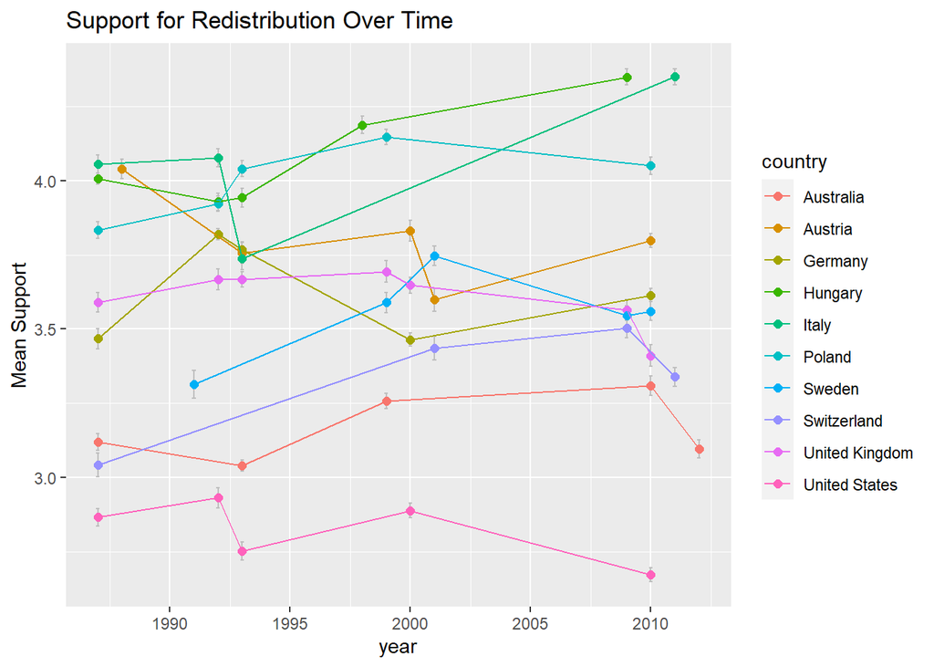

```r
# make a label variable
df$lab <- countrycode(df$cntry, "iso3n", "iso2c")
df$lab <- paste0(df$lab,df$year)

fig1 <- df %>%
  group_by(cyear) %>%
  mutate(reduceM = mean(reduce, na.rm = T),
         reduceSE = (sd(reduce, na.rm = T)/sqrt(length(which(!is.na(reduce))))))


fig1 <- dplyr::select(fig1, year, cyear, lab, reduceM, reduceSE, wave, cntry)

fig1 <- aggregate(fig1,  by=list(fig1$lab), FUN=mean, na.rm=T)
colnames(fig1) <- c("lab","year","cyear","skip","reduceM","reduceSE","wave","cntry")

fig1$country <- countrycode(fig1$cntry, "iso3n", "country.name")

# only label countries that are in the survey often)
cntry2 <- as.list(unique(fig1$cntry[fig1$year < 1992]))
fig1$country <- ifelse(fig1$cntry  %in% cntry2, fig1$country, NA)

# drop NA countries
fig1a <- subset(fig1, !is.na(country))
ggplot(fig1a, aes(x=year, y=reduceM, color=country)) +
    geom_errorbar(aes(ymin=reduceM-reduceSE, ymax=reduceM+reduceSE), colour="grey", width = .15) +
    geom_point(size=2) +
    geom_line() +
    labs(title = "Support for Redistribution Over Time") +
    ylab(label = "Mean Support")
```

## Table 3. Correlations, Pooled

```r
tab2 <- dplyr::select(tab2, reduce, everything())
cor1 <- cor(tab2, use = "pairwise.complete.obs")
cor1k <- kable(cor1, digits = 2)
kable_styling(cor1k)
```

|  | reduce | year | ageC | female | educyrs | child | married | rincZ | hincZ | isei | egp_un | egp_skl | egp_othr | egp_rou | egp_svc2 | egp_svc1 | sh_groups_1 | sh_groups_2 | sh_groups_3 | sh_groups_4 | sh_groups_5 | sh_groups_new_1 | sh_groups_new_2 | sh_groups_new_3 | sh_groups_new_4 | sh_groups_new_5 | wk_full | wk_part | wk_lesspart | … |
| --- | --- | --- | --- | --- | --- | --- | --- | --- | --- | --- | --- | --- | --- | --- | --- | --- | --- | --- | --- | --- | --- | --- | --- | --- | --- | --- | --- | --- | --- | --- |
| reduce | 1.00 | 0.05 | 0.06 | 0.06 | -0.16 | -0.03 | 0.01 | -0.15 | -0.17 | -0.18 | 0.05 | 0.14 | -0.06 | 0.02 | -0.06 | -0.11 | -0.17 | -0.02 | 0.12 | 0.01 | 0.06 | -0.17 | -0.02 | 0.12 | 0.01 | 0.06 | -0.07 | -0.02 | -0.01 | … |
| year | 0.05 | 1.00 | 0.09 | 0.02 | 0.13 | -0.07 | -0.06 | 0.00 | 0.00 | 0.02 | -0.02 | -0.03 | 0.06 | 0.04 | 0.01 | 0.00 | 0.00 | 0.00 | -0.06 | 0.03 | 0.05 | 0.01 | 0.00 | -0.06 | 0.03 | 0.04 | 0.06 | 0.05 | 0.03 | … |
| ageC | 0.06 | 0.09 | 1.00 | 0.02 | -0.23 | -0.37 | 0.40 | -0.02 | -0.22 | -0.03 | 0.08 | 0.00 | 0.05 | -0.07 | -0.02 | 0.02 | 0.01 | -0.03 | 0.06 | 0.00 | -0.05 | 0.01 | -0.03 | 0.06 | 0.00 | -0.05 | -0.26 | -0.05 | -0.03 | … |
| female | 0.06 | 0.02 | 0.02 | 1.00 | -0.04 | 0.04 | 0.02 | -0.29 | -0.10 | 0.00 | -0.04 | -0.15 | -0.09 | 0.27 | 0.05 | -0.07 | -0.05 | 0.10 | -0.31 | 0.15 | 0.21 | -0.05 | 0.10 | -0.31 | 0.15 | 0.21 | -0.20 | 0.11 | 0.03 | … |
| educyrs | -0.16 | 0.13 | -0.23 | -0.04 | 1.00 | 0.04 | -0.12 | 0.30 | 0.34 | 0.54 | -0.19 | -0.32 | -0.05 | 0.03 | 0.26 | 0.30 | 0.35 | 0.04 | -0.37 | 0.26 | -0.17 | 0.35 | 0.04 | -0.37 | 0.26 | -0.17 | 0.24 | 0.06 | 0.00 | … |
| child | -0.03 | -0.07 | -0.37 | 0.04 | 0.04 | 1.00 | 0.11 | 0.07 | 0.19 | 0.00 | -0.02 | -0.01 | 0.03 | 0.00 | 0.00 | 0.00 | 0.00 | -0.02 | -0.01 | 0.01 | 0.02 | 0.00 | -0.02 | -0.01 | 0.01 | 0.02 | 0.14 | 0.06 | 0.03 | … |
| married | 0.01 | -0.06 | 0.40 | 0.02 | -0.12 | 0.11 | 1.00 | 0.08 | 0.11 | 0.00 | 0.03 | -0.02 | 0.05 | -0.05 | -0.01 | 0.02 | 0.03 | -0.02 | 0.04 | 0.00 | -0.05 | 0.03 | -0.02 | 0.04 | 0.00 | -0.05 | -0.03 | 0.00 | -0.01 | … |
| rincZ | -0.15 | 0.00 | -0.02 | -0.29 | 0.30 | 0.07 | 0.08 | 1.00 | 0.57 | 0.35 | -0.10 | -0.16 | 0.04 | -0.12 | 0.14 | 0.23 | 0.28 | -0.02 | -0.10 | 0.06 | -0.23 | 0.28 | -0.02 | -0.10 | 0.06 | -0.23 | 0.49 | -0.08 | -0.06 | … |
| hincZ | -0.17 | 0.00 | -0.22 | -0.10 | 0.34 | 0.19 | 0.11 | 0.57 | 1.00 | 0.34 | -0.13 | -0.19 | 0.02 | -0.02 | 0.14 | 0.19 | 0.25 | 0.02 | -0.19 | 0.09 | -0.15 | 0.25 | 0.02 | -0.19 | 0.09 | -0.15 | 0.32 | 0.02 | -0.02 | … |
| isei | -0.18 | 0.02 | -0.03 | 0.00 | 0.54 | 0.00 | 0.00 | 0.35 | 0.34 | 1.00 | -0.26 | -0.58 | -0.02 | 0.01 | 0.37 | 0.58 | 0.65 | 0.11 | -0.54 | 0.25 | -0.36 | 0.65 | 0.11 | -0.54 | 0.25 | -0.36 | 0.13 | -0.01 | -0.03 | … |
| egp_un | 0.05 | -0.02 | 0.08 | -0.04 | -0.19 | -0.02 | 0.03 | -0.10 | -0.13 | -0.26 | 1.00 | -0.14 | -0.07 | -0.11 | -0.10 | -0.07 | -0.10 | -0.08 | 0.29 | -0.06 | -0.10 | -0.10 | -0.08 | 0.29 | -0.06 | -0.10 | -0.06 | -0.02 | 0.01 | … |
| egp_skl | 0.14 | -0.03 | 0.00 | -0.15 | -0.32 | -0.01 | -0.02 | -0.16 | -0.19 | -0.58 | -0.14 | 1.00 | -0.24 | -0.37 | -0.34 | -0.24 | -0.43 | -0.27 | 0.57 | -0.23 | 0.22 | -0.43 | -0.27 | 0.57 | -0.23 | 0.22 | -0.05 | -0.05 | -0.01 | … |
| egp_othr | -0.06 | 0.06 | 0.05 | -0.09 | -0.05 | 0.03 | 0.05 | 0.04 | 0.02 | -0.02 | -0.07 | -0.24 | 1.00 | -0.18 | -0.16 | -0.12 | 0.08 | -0.09 | 0.06 | -0.07 | -0.02 | 0.08 | -0.09 | 0.06 | -0.07 | -0.02 | 0.06 | 0.03 | 0.05 | … |
| egp_rou | 0.02 | 0.04 | -0.07 | 0.27 | 0.03 | 0.00 | -0.05 | -0.12 | -0.02 | 0.01 | -0.11 | -0.37 | -0.18 | 1.00 | -0.25 | -0.18 | -0.20 | 0.50 | -0.35 | 0.04 | 0.15 | -0.20 | 0.50 | -0.35 | 0.04 | 0.15 | -0.06 | 0.07 | 0.01 | … |
| egp_svc2 | -0.06 | 0.01 | -0.02 | 0.05 | 0.26 | 0.00 | -0.01 | 0.14 | 0.14 | 0.37 | -0.10 | -0.34 | -0.16 | -0.25 | 1.00 | -0.17 | 0.29 | 0.02 | -0.32 | 0.34 | -0.22 | 0.29 | 0.02 | -0.32 | 0.34 | -0.22 | 0.06 | 0.01 | -0.02 | … |
| egp_svc1 | -0.11 | 0.00 | 0.02 | -0.07 | 0.30 | 0.00 | 0.02 | 0.23 | 0.19 | 0.58 | -0.07 | -0.24 | -0.12 | -0.18 | -0.17 | 1.00 | 0.52 | -0.14 | -0.23 | -0.03 | -0.17 | 0.52 | -0.14 | -0.23 | -0.03 | -0.17 | 0.08 | -0.05 | -0.03 | … |
| sh_groups_1 | -0.17 | 0.00 | 0.01 | -0.05 | 0.35 | 0.00 | 0.03 | 0.28 | 0.25 | 0.65 | -0.10 | -0.43 | 0.08 | -0.20 | 0.29 | 0.52 | 1.00 | -0.24 | -0.40 | -0.19 | -0.30 | 1.00 | -0.24 | -0.40 | -0.19 | -0.30 | 0.12 | -0.03 | -0.02 | … |
| sh_groups_2 | -0.02 | 0.00 | -0.03 | 0.10 | 0.04 | -0.02 | -0.02 | -0.02 | 0.02 | 0.11 | -0.08 | -0.27 | -0.09 | 0.50 | 0.02 | -0.14 | -0.24 | 1.00 | -0.27 | -0.13 | -0.20 | -0.24 | 1.00 | -0.27 | -0.13 | -0.20 | 0.00 | 0.02 | -0.01 | … |
| sh_groups_3 | 0.12 | -0.06 | 0.06 | -0.31 | -0.37 | -0.01 | 0.04 | -0.10 | -0.19 | -0.54 | 0.29 | 0.57 | 0.06 | -0.35 | -0.32 | -0.23 | -0.40 | -0.27 | 1.00 | -0.21 | -0.33 | -0.40 | -0.27 | 1.00 | -0.21 | -0.33 | -0.01 | -0.11 | -0.01 | … |
| sh_groups_4 | 0.01 | 0.03 | 0.00 | 0.15 | 0.26 | 0.01 | 0.00 | 0.06 | 0.09 | 0.25 | -0.06 | -0.23 | -0.07 | 0.04 | 0.34 | -0.03 | -0.19 | -0.13 | -0.21 | 1.00 | -0.16 | -0.19 | -0.13 | -0.21 | 1.00 | -0.16 | 0.00 | 0.06 | 0.01 | … |
| sh_groups_5 | 0.06 | 0.05 | -0.05 | 0.21 | -0.17 | 0.02 | -0.05 | -0.23 | -0.15 | -0.36 | -0.10 | 0.22 | -0.02 | 0.15 | -0.22 | -0.17 | -0.30 | -0.20 | -0.33 | -0.16 | 1.00 | -0.30 | -0.20 | -0.33 | -0.16 | 1.00 | -0.11 | 0.09 | 0.04 | … |
| sh_groups_new_1 | -0.17 | 0.01 | 0.01 | -0.05 | 0.35 | 0.00 | 0.03 | 0.28 | 0.25 | 0.65 | -0.10 | -0.43 | 0.08 | -0.20 | 0.29 | 0.52 | 1.00 | -0.24 | -0.40 | -0.19 | -0.30 | 1.00 | -0.24 | -0.39 | -0.19 | -0.30 | 0.12 | -0.03 | -0.02 | … |
| sh_groups_new_2 | -0.02 | 0.00 | -0.03 | 0.10 | 0.04 | -0.02 | -0.02 | -0.02 | 0.02 | 0.11 | -0.08 | -0.27 | -0.09 | 0.50 | 0.02 | -0.14 | -0.24 | 1.00 | -0.27 | -0.13 | -0.20 | -0.24 | 1.00 | -0.27 | -0.13 | -0.20 | 0.00 | 0.02 | -0.01 | … |
| sh_groups_new_3 | 0.12 | -0.06 | 0.06 | -0.31 | -0.37 | -0.01 | 0.04 | -0.10 | -0.19 | -0.54 | 0.29 | 0.57 | 0.06 | -0.35 | -0.32 | -0.23 | -0.40 | -0.27 | 1.00 | -0.21 | -0.33 | -0.39 | -0.27 | 1.00 | -0.21 | -0.33 | -0.01 | -0.11 | -0.01 | … |
| sh_groups_new_4 | 0.01 | 0.03 | 0.00 | 0.15 | 0.26 | 0.01 | 0.00 | 0.06 | 0.09 | 0.25 | -0.06 | -0.23 | -0.07 | 0.04 | 0.34 | -0.03 | -0.19 | -0.13 | -0.21 | 1.00 | -0.16 | -0.19 | -0.13 | -0.21 | 1.00 | -0.16 | 0.00 | 0.06 | 0.01 | … |
| sh_groups_new_5 | 0.06 | 0.04 | -0.05 | 0.21 | -0.17 | 0.02 | -0.05 | -0.23 | -0.15 | -0.36 | -0.10 | 0.22 | -0.02 | 0.15 | -0.22 | -0.17 | -0.30 | -0.20 | -0.33 | -0.16 | 1.00 | -0.30 | -0.20 | -0.33 | -0.16 | 1.00 | -0.11 | 0.09 | 0.04 | … |
| wk_full | -0.07 | 0.06 | -0.26 | -0.20 | 0.24 | 0.14 | -0.03 | 0.49 | 0.32 | 0.13 | -0.06 | -0.05 | 0.06 | -0.06 | 0.06 | 0.08 | 0.12 | 0.00 | -0.01 | 0.00 | -0.11 | 0.12 | 0.00 | -0.01 | 0.00 | -0.11 | 1.00 | -0.24 | -0.12 | … |
| wk_part | -0.02 | 0.05 | -0.05 | 0.11 | 0.06 | 0.06 | 0.00 | -0.08 | 0.02 | -0.01 | -0.02 | -0.05 | 0.03 | 0.07 | 0.01 | -0.05 | -0.03 | 0.02 | -0.11 | 0.06 | 0.09 | -0.03 | 0.02 | -0.11 | 0.06 | 0.09 | -0.24 | 1.00 | -0.04 | … |
| wk_lesspart | -0.01 | 0.03 | -0.03 | 0.03 | 0.00 | 0.03 | -0.01 | -0.06 | -0.02 | -0.03 | 0.01 | -0.01 | 0.05 | 0.01 | -0.02 | -0.03 | -0.02 | -0.01 | -0.01 | 0.01 | 0.04 | -0.02 | -0.01 | -0.01 | 0.01 | 0.04 | -0.12 | -0.04 | 1.00 | … |
| wk_unemp | 0.05 | 0.04 | -0.12 | -0.02 | -0.04 | 0.04 | -0.10 | -0.19 | -0.12 | -0.08 | 0.01 | 0.09 | -0.04 | 0.00 | -0.05 | -0.04 | -0.06 | -0.02 | 0.07 | -0.04 | 0.04 | -0.06 | -0.02 | 0.07 | -0.04 | 0.04 | -0.21 | -0.07 | -0.03 | … |
| wk_school | -0.02 | 0.03 | -0.34 | 0.00 | 0.04 | 0.03 | -0.30 | -0.22 | -0.01 | -0.02 | -0.01 | 0.01 | -0.03 | 0.04 | -0.01 | -0.02 | -0.03 | 0.01 | -0.03 | -0.01 | 0.07 | -0.03 | 0.01 | -0.03 | -0.01 | 0.07 | -0.20 | -0.07 | -0.03 | … |
| wk_retired | 0.09 | 0.07 | 0.62 | -0.01 | -0.18 | -0.33 | 0.18 | -0.16 | -0.25 | -0.04 | 0.07 | 0.04 | -0.05 | -0.02 | -0.02 | 0.00 | -0.03 | 0.00 | 0.06 | 0.00 | -0.03 | -0.03 | 0.00 | 0.06 | 0.00 | -0.03 | -0.42 | -0.13 | -0.07 | … |
| wk_home | 0.00 | -0.01 | 0.01 | 0.26 | -0.13 | 0.11 | 0.13 | -0.19 | -0.07 | -0.05 | 0.01 | -0.01 | -0.01 | 0.07 | -0.02 | -0.04 | -0.05 | 0.03 | -0.03 | -0.01 | 0.08 | -0.05 | 0.03 | -0.03 | -0.01 | 0.08 | -0.28 | -0.09 | -0.04 | … |
| wk_disab | 0.04 | 0.04 | 0.06 | 0.00 | -0.05 | -0.06 | -0.01 | -0.09 | -0.08 | -0.05 | 0.01 | 0.04 | 0.00 | -0.01 | -0.02 | -0.02 | -0.03 | -0.01 | 0.03 | -0.01 | 0.02 | -0.04 | -0.01 | 0.03 | -0.02 | 0.02 | -0.12 | -0.04 | -0.02 | … |
| wk_other | 0.01 | -0.19 | 0.03 | 0.05 | -0.07 | 0.00 | 0.01 | -0.09 | -0.08 | -0.03 | 0.02 | 0.02 | -0.02 | 0.00 | -0.02 | -0.01 | -0.02 | 0.00 | 0.02 | -0.01 | 0.01 | -0.02 | -0.01 | 0.02 | -0.01 | 0.01 | -0.17 | -0.06 | -0.03 | … |
| wrkhrs | -0.07 | -0.30 | -0.22 | -0.20 | 0.13 | 0.14 | 0.00 | 0.42 | 0.25 | 0.07 | 0.02 | -0.03 | 0.05 | -0.09 | 0.01 | 0.06 | 0.10 | -0.04 | 0.06 | -0.05 | -0.10 | 0.10 | -0.04 | 0.06 | -0.05 | -0.10 | 0.70 | -0.16 | -0.16 | … |
| union | 0.02 | -0.11 | -0.03 | -0.05 | 0.13 | 0.02 | 0.04 | 0.17 | 0.12 | 0.08 | -0.07 | 0.02 | -0.10 | -0.01 | 0.09 | 0.03 | 0.00 | 0.02 | -0.03 | 0.13 | -0.07 | 0.00 | 0.02 | -0.03 | 0.13 | -0.08 | 0.21 | 0.00 | -0.03 | … |
| sparent | 0.00 | 0.11 | -0.14 | 0.08 | -0.01 | 0.30 | -0.28 | -0.04 | -0.08 | -0.04 | -0.01 | 0.01 | 0.00 | 0.03 | -0.01 | -0.03 | -0.03 | 0.00 | -0.03 | 0.01 | 0.07 | -0.03 | 0.00 | -0.03 | 0.01 | 0.07 | -0.02 | 0.02 | 0.02 | … |

```r
# check that correlations look 'right'
```

# Group Comparisons

1 “Capital accumulators” 2 “Mixed service functionaires” 3 “Blue and lower white collar” 4 “Socio-cultural (semi-)professionals” 5 “Low service functionaires”

### Fig 2. Germany

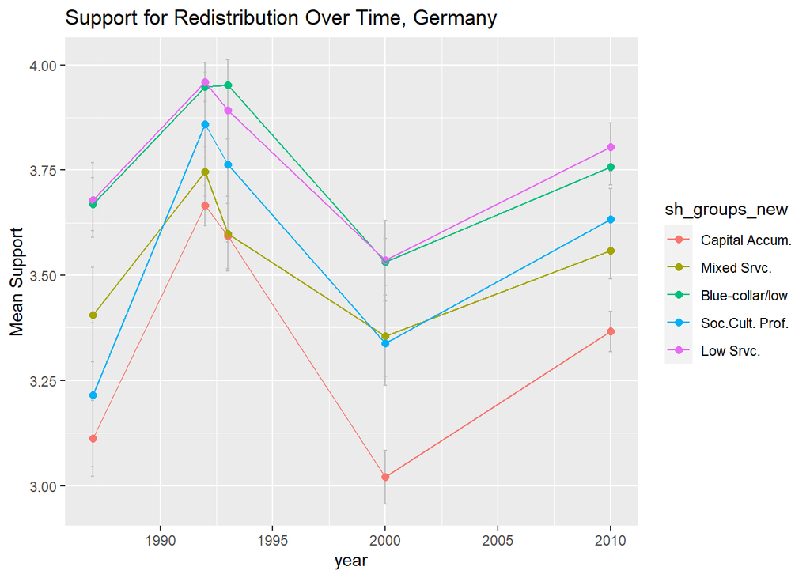

```r
fig2 <- df %>%
  group_by(cyear, sh_groups_new) %>%
    mutate(reduceM = mean(reduce, na.rm = T),
           reduceSE = (sd(reduce, na.rm = T)/sqrt(length(which(!is.na(reduce))))))

fig2 <- dplyr::select(fig2, year, cyear, lab, reduceM, reduceSE, wave, cntry, sh_groups_new)

fig2 <- aggregate(fig2,  by=list(fig2$cyear,fig2$sh_groups_new), FUN=mean, na.rm=T)

fig2de <- subset(fig2, cntry == 276)
fig2de$sh_groups_new <- as.factor(fig2de$sh_groups_new)

ggplot(fig2de, aes(x=year, y=reduceM, color=sh_groups_new)) +
    geom_errorbar(aes(ymin=reduceM-reduceSE, ymax=reduceM+reduceSE), colour="grey", width = .15) +
    geom_point(size=2) +
    geom_line() +
    labs(title = "Support for Redistribution Over Time, Germany") +
    ylab(label = "Mean Support") +
    scale_color_hue(labels = c("Capital Accum.", "Mixed Srvc.", "Blue-collar/low", "Soc.Cult. Prof.", "Low Srvc."))
```

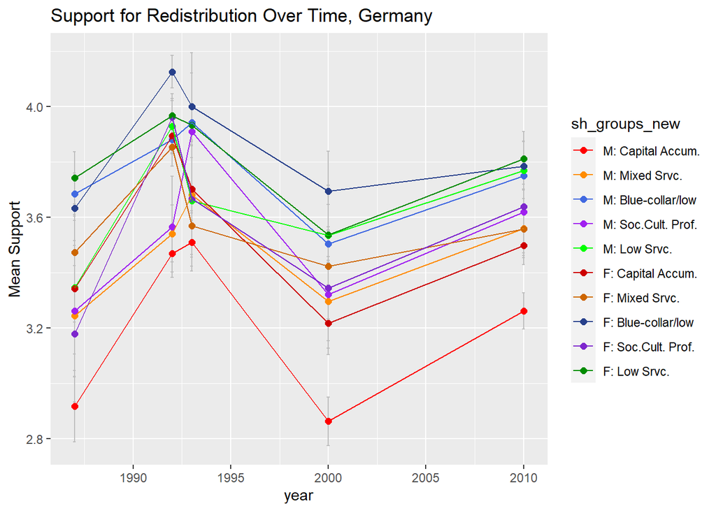

```r
fig2g <- df %>%
  group_by(cyear, sh_groups_new, female) %>%
    mutate(reduceM = mean(reduce, na.rm = T),
           reduceSE = (sd(reduce, na.rm = T)/sqrt(length(which(!is.na(reduce))))))

fig2g <- dplyr::select(fig2g, year, cyear, lab, reduceM, reduceSE, wave, cntry, sh_groups_new, female)
fig2g$sh_groups_new_g <- fig2g$sh_groups_new + (5*fig2g$female)
fig2g <- subset(fig2g, select = -c(sh_groups_new, female))

fig2g <- aggregate(fig2g,  by=list(fig2g$cyear,fig2g$sh_groups_new_g), FUN=mean, na.rm=T)

fig2gde <- subset(fig2g, cntry == 276)
fig2gde$sh_groups_new <- as.factor(fig2gde$sh_groups_new)

ggplot(fig2gde, aes(x=year, y=reduceM, color=sh_groups_new)) +
    geom_errorbar(aes(ymin=reduceM-reduceSE, ymax=reduceM+reduceSE), colour="grey", width = .15) +
    geom_point(size=2) +
    geom_line() +
    labs(title = "Support for Redistribution Over Time, Germany") +
    ylab(label = "Mean Support") +
    scale_color_manual(labels = c("M: Capital Accum.", "M: Mixed Srvc.", "M: Blue-collar/low", "M: Soc.Cult. Prof.", "M: Low Srvc.", "F: Capital Accum.", "F: Mixed Srvc.", "F: Blue-collar/low", "F: Soc.Cult. Prof.", "F: Low Srvc."), values = c("red", "darkorange", "royalblue", "purple", "green", "red3", "darkorange3", "royalblue4", "purple3", "green4"))
```

### Welfare State and Redistributive Prefs

Decommodification data from CWED2 Government Consumption Data from OECD Government Spending Data from OECD Pre- Post- Gini from Solt

```r
# get from github
pacman::p_load(readr)
cwed <- read_csv("https://raw.githubusercontent.com/hungnguyen167/Social-Status/master/cwed-subset.csv?token=AGMAHBX3HBSAPIGWMSG4FB27GOJM2")

cwed$cntry <- countrycode(cwed$COUNTRY, "country.name", "iso3n")
cwed$year <- cwed$YEAR

cweds <- dplyr::select(cwed, cntry, year, TOTGEN, UEGEN, SKGEN, PGEN)

# Get other data later
```

```r
tab_macro <- fig2 %>%
  mutate(year2 = year,
         year = ifelse(year > 2010, 2010, ifelse(year < 1987, 1987, year))
  )

tab_macro <- left_join(tab_macro,cweds, by = c("cntry","year"))

tab_macro$year <- tab_macro$year2
tab_macro <- dplyr::select(tab_macro, cntry, year, sh_groups_new, TOTGEN, reduceM, reduceSE)
tab_macro <- tab_macro[order(tab_macro$cntry, tab_macro$year),]
tab_macro <- subset(tab_macro, !is.na(tab_macro$TOTGEN))

# get aggregate scores by country/year
# mean
t_mean <- aggregate(tab_macro, by = list(tab_macro$cntry, tab_macro$year), FUN = mean)
t_min <- aggregate(tab_macro, by = list(tab_macro$cntry, tab_macro$year), FUN = min)
t_max <- aggregate(tab_macro, by = list(tab_macro$cntry, tab_macro$year), FUN = max)

# clean
t_mean <- dplyr::select(t_mean, cntry, year, TOTGEN, reduceM, reduceSE)

t_min$min <- t_min$reduceM
t_min <- dplyr::select(t_min, cntry, year, min)

t_max$max <- t_max$reduceM
t_max <- dplyr::select(t_max, cntry, year, max)

t_max <- left_join(t_max, t_min, by = c("cntry", "year"))
t_max$range <- t_max$max - t_max$min
t_max <- dplyr::select(t_max, cntry, year, range)

tab_macro <- left_join(t_mean, t_max, by = c("cntry","year"))

tab_macro <- tab_macro[order(tab_macro$TOTGEN, tab_macro$cntry, tab_macro$year),]


tab1_m <- kable(tab_macro)

kable_styling(tab1_m)
```

|  | cntry | year | TOTGEN | reduceM | reduceSE | range |
| --- | --- | --- | --- | --- | --- | --- |
| 67 | 410 | 2010 | 14.5 | 3.809554 | 0.0679462 | 0.2846295 |
| 3 | 840 | 1987 | 19.9 | 2.901640 | 0.0798256 | 0.4848510 |
| 59 | 36 | 2010 | 20.9 | 3.353861 | 0.0813529 | 0.6098891 |
| 79 | 36 | 2012 | 20.9 | 3.127313 | 0.0772845 | 0.3436409 |
| 17 | 554 | 1993 | 21.2 | 2.981300 | 0.1592918 | 0.1764241 |
| 20 | 840 | 1993 | 21.3 | 2.778612 | 0.0767875 | 0.7558923 |
| 8 | 554 | 1992 | 21.4 | 3.263561 | 0.1089855 | 0.5694083 |
| 68 | 554 | 2010 | 21.4 | 3.001493 | 0.1143403 | 0.5827180 |
| 43 | 840 | 2000 | 21.4 | 2.928636 | 0.0613603 | 0.5593983 |
| 52 | 554 | 2009 | 21.5 | 3.061685 | 0.1263759 | 0.4194583 |
| 10 | 840 | 1992 | 21.5 | 2.953775 | 0.0827057 | 0.6811358 |
| 26 | 554 | 1999 | 21.7 | 3.230697 | 0.1201931 | 0.6804855 |
| 38 | 554 | 2000 | 21.7 | 2.937670 | 0.1213009 | 0.5697998 |
| 73 | 840 | 2010 | 21.7 | 2.688233 | 0.0571982 | 0.3647150 |
| 22 | 36 | 1999 | 21.8 | 3.271203 | 0.0661572 | 0.3999364 |
| 11 | 36 | 1993 | 22.3 | 3.041550 | 0.0498080 | 0.5635087 |
| 15 | 372 | 1993 | 24.2 | 3.842786 | 0.1032753 | 0.7639797 |
| 25 | 392 | 1999 | 24.9 | 3.425555 | 0.1062074 | 0.6330361 |
| 36 | 392 | 2000 | 25.4 | 3.368421 | 0.1085718 | 0.0000000 |
| 74 | 124 | 2011 | 25.7 | 3.348571 | 0.1096547 | 0.1994944 |
| 66 | 392 | 2010 | 25.7 | 3.592309 | 0.1045561 | 0.4885587 |
| 23 | 124 | 1999 | 25.9 | 3.193186 | 0.1126291 | 0.6251082 |
| 45 | 124 | 2001 | 26.0 | 3.286194 | 0.1111487 | 0.5599460 |
| 51 | 392 | 2009 | 26.0 | 3.458124 | 0.1050358 | 0.4244992 |
| 13 | 124 | 1993 | 26.2 | 2.853538 | 0.2095200 | 0.5769231 |
| 19 | 826 | 1993 | 26.3 | 3.540550 | 0.0747792 | 0.7292021 |
| 6 | 124 | 1992 | 26.4 | 3.282720 | 0.1147352 | 0.3377371 |
| 31 | 826 | 1999 | 27.0 | 3.717789 | 0.0875996 | 0.5087025 |
| 42 | 826 | 2000 | 27.3 | 3.629984 | 0.0652707 | 0.7069274 |
| 72 | 826 | 2010 | 27.5 | 3.397597 | 0.0847198 | 0.4850241 |
| 16 | 380 | 1993 | 27.8 | 3.595758 | 0.1223348 | 0.5911496 |
| 58 | 826 | 2009 | 28.2 | 3.571065 | 0.0792508 | 0.5484471 |
| 75 | 380 | 2011 | 29.6 | 4.397940 | 0.0677082 | 0.4785228 |
| 28 | 620 | 1999 | 30.5 | 4.472423 | 0.0833635 | 0.3570164 |
| 40 | 620 | 2000 | 31.1 | 4.128366 | 0.0948466 | 0.3242985 |
| 12 | 40 | 1993 | 31.7 | 3.619688 | 0.1283518 | 0.7433743 |
| 21 | 724 | 1994 | 31.9 | 3.666365 | 0.1332286 | 0.3321123 |
| 4 | 40 | 1988 | 32.0 | 4.016577 | 0.0934406 | 0.4945893 |
| 65 | 276 | 2010 | 32.0 | 3.624082 | 0.0576122 | 0.4378837 |
| 32 | 40 | 2000 | 32.2 | 3.717191 | 0.1139704 | 0.7540835 |
| 29 | 724 | 1999 | 33.5 | 3.967903 | 0.0847739 | 0.3008229 |
| 44 | 40 | 2001 | 33.6 | 3.496101 | 0.1003695 | 0.8850265 |
| 47 | 372 | 2001 | 33.6 | 3.696960 | 0.0593155 | 0.4385158 |
| 41 | 724 | 2000 | 33.7 | 3.860259 | 0.1346068 | 0.3965876 |
| 62 | 208 | 2010 | 34.1 | 3.527574 | 0.0880596 | 0.6306787 |
| 63 | 246 | 2010 | 34.1 | 3.981441 | 0.0749038 | 0.6213483 |
| 60 | 40 | 2010 | 34.3 | 3.795664 | 0.0588398 | 0.4652094 |
| 34 | 246 | 2000 | 34.6 | 4.023043 | 0.0731246 | 0.5489491 |
| 69 | 620 | 2010 | 35.1 | 4.005733 | 0.0721953 | 0.3604758 |
| 35 | 276 | 2000 | 35.2 | 3.356413 | 0.0820256 | 0.5149067 |
| 54 | 620 | 2009 | 35.2 | 4.416572 | 0.0612448 | 0.1757576 |
| 71 | 752 | 2010 | 35.2 | 3.574341 | 0.0762798 | 0.6615986 |
| 55 | 724 | 2009 | 35.4 | 3.941037 | 0.0808142 | 0.2140793 |
| 56 | 752 | 2009 | 35.5 | 3.553096 | 0.0789219 | 0.7573931 |
| 70 | 724 | 2010 | 35.6 | 3.896607 | 0.0608701 | 0.2426518 |
| 46 | 208 | 2001 | 35.7 | 3.287838 | 0.1227963 | 0.7401142 |
| 33 | 208 | 2000 | 35.9 | 3.115405 | 0.1031047 | 0.8331709 |
| 2 | 756 | 1987 | 36.1 | 3.132218 | 0.1041943 | 0.6601663 |
| 1 | 276 | 1987 | 36.2 | 3.416420 | 0.1050763 | 0.5666528 |
| 14 | 276 | 1993 | 36.6 | 3.759972 | 0.0961228 | 0.3593758 |
| 49 | 756 | 2001 | 36.6 | 3.456164 | 0.1229648 | 0.6692268 |
| 24 | 250 | 1999 | 36.7 | 3.846078 | 0.0854132 | 0.6832574 |
| 7 | 276 | 1992 | 36.8 | 3.835649 | 0.0532053 | 0.2934865 |
| 57 | 756 | 2009 | 36.8 | 3.522621 | 0.0772392 | 0.6033643 |
| 78 | 756 | 2011 | 37.1 | 3.338329 | 0.0749118 | 0.4323764 |
| 37 | 528 | 2000 | 37.2 | 3.055658 | 0.0602386 | 0.1867306 |
| 50 | 250 | 2009 | 37.9 | 4.218823 | 0.0468003 | 0.5459783 |
| 64 | 250 | 2010 | 38.0 | 4.024023 | 0.0619083 | 0.5509727 |
| 76 | 528 | 2011 | 38.6 | 3.626446 | 0.0748919 | 0.4081653 |
| 80 | 528 | 2013 | 38.6 | 3.743022 | 0.0746240 | 0.7132887 |
| 48 | 752 | 2001 | 40.2 | 3.731516 | 0.0799086 | 0.6180556 |
| 30 | 752 | 1999 | 40.8 | 3.609470 | 0.0829859 | 0.8778732 |
| 9 | 578 | 1992 | 41.9 | 3.486801 | 0.0730801 | 0.7949370 |
| 18 | 578 | 1993 | 42.0 | 3.405400 | 0.1081692 | 0.8031250 |
| 61 | 56 | 2010 | 42.6 | 3.867395 | 0.0743217 | 0.3341008 |
| 27 | 578 | 1999 | 42.6 | 3.595561 | 0.0761168 | 0.6954990 |
| 39 | 578 | 2000 | 42.9 | 3.637207 | 0.0665874 | 0.5683304 |
| 53 | 578 | 2009 | 43.4 | 3.402166 | 0.0677814 | 0.4944006 |
| 77 | 578 | 2011 | 43.9 | 3.443596 | 0.0703610 | 0.5806986 |
| 5 | 752 | 1991 | 45.6 | 3.307516 | 0.1127787 | 0.7273524 |

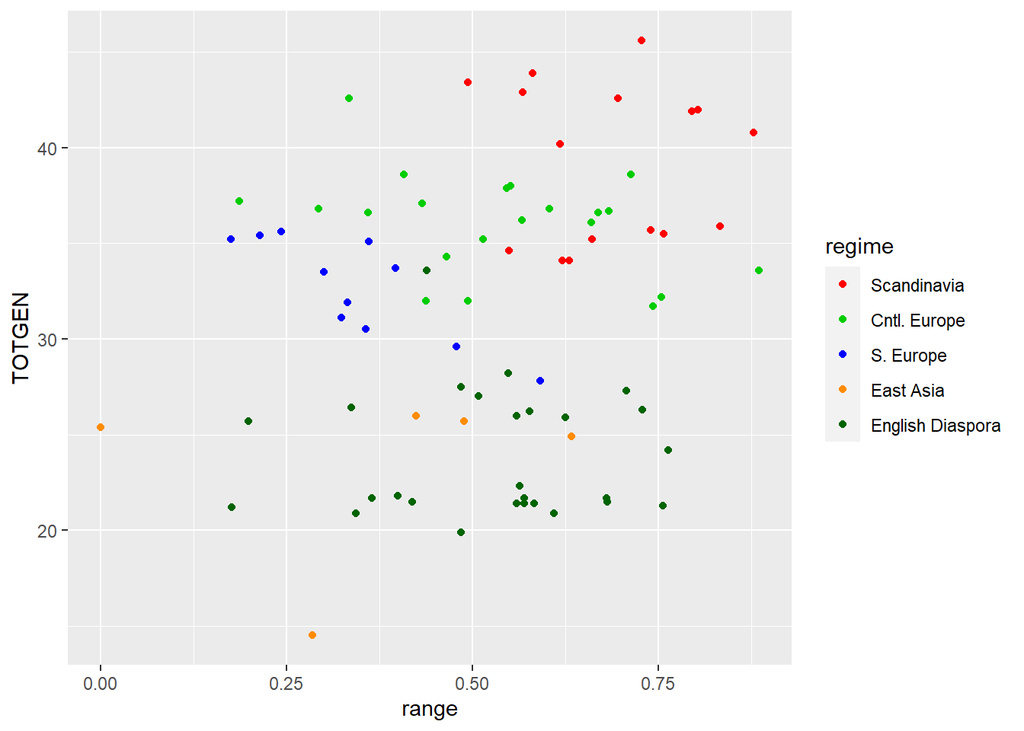

```r
# create regime variable

tab_macro <- tab_macro %>%
  mutate(regime = case_when(
    cntry == 752 | cntry == 208 | cntry == 578 | cntry == 246 ~ 1,
    cntry == 276 | cntry == 250 | cntry == 56 | cntry == 528 | cntry == 40 | cntry == 756 ~ 2,
    cntry == 724 | cntry == 620 | cntry == 380 ~ 3,
    cntry == 392 | cntry == 410 ~ 4,
    cntry == 36 | cntry == 840 | cntry == 554 | cntry == 826 | cntry == 372 | cntry == 124 ~ 5
  ))

tab_macro$regime <- as.factor(tab_macro$regime)

ggplot(tab_macro, aes(y = TOTGEN, x = range, color = regime)) +
  geom_point() +
  scale_color_manual(labels = c("Scandinavia", "Cntl. Europe", "S. Europe", "East Asia", "English Diaspora"), values = c("red", "green3", "blue", "darkorange",  "darkgreen"))
```

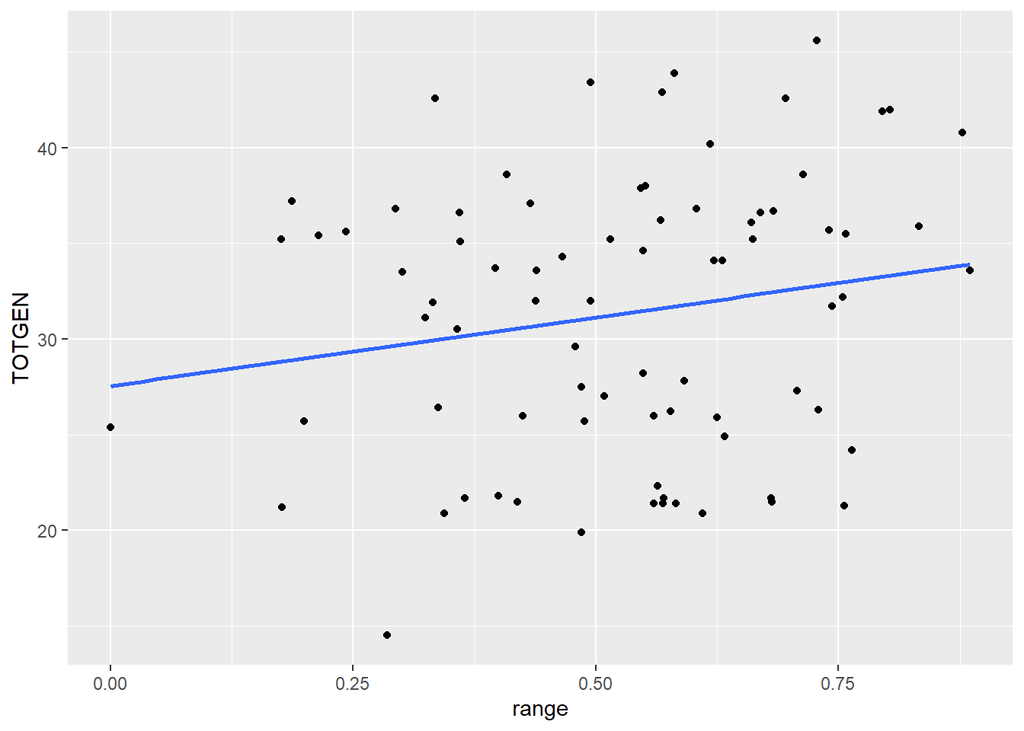

```r
ggplot(tab_macro, aes(y = TOTGEN, x = range)) +
  geom_point() +
  geom_smooth(method=lm, se=FALSE)
```

### Risk and Redistributive Preferences

```r
# make risk-based categorizations

df <- df %>%
  group_by(cyear) %>%
  mutate(atrisk = ifelse(wk_unemp == 1 | wk_lesspart == 1, 1, 0),
    risk_cymean = mean(atrisk, na.rm = T))

df <- df %>%
  group_by(cyear, sh_groups) %>%
  mutate(risk_gcymean = mean(atrisk, na.rm =T),
         risk_gcyse = (sd(atrisk, na.rm=T)/sqrt(length(which(!is.na(atrisk))))),
         risk_grp_rate = risk_gcymean - risk_cymean,
         count = sum(!is.na(sh_groups))) %>%
  ungroup()



tab3 <- dplyr::select(df, sh_groups, cntry, year, reduce, risk_grp_rate, risk_gcyse, count)
tab3 <- subset(tab3, !is.na(tab3$sh_groups))
tab3 <- aggregate(tab3, by = list(tab3$cntry, tab3$year, tab3$sh_groups), FUN=mean, na.rm=T)
tab3 <- tab3[-c(1:3)]
tab3 <- tab3 %>%
  mutate(risk_grp_rate = ifelse(risk_grp_rate == "NaN", NA, round(risk_grp_rate, 3)),
         risk_gcyse = ifelse(risk_gcyse=="NaN", NA, ifelse(risk_gcyse!=0, round(risk_gcyse,3), 0.001)))

tab3de <- subset(tab3, tab3$cntry==276)

# Make DE-specific table later
```

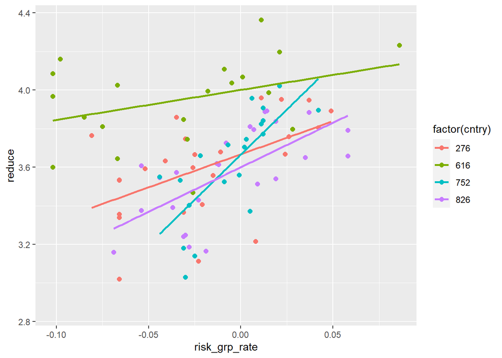

```r
tab3simp <- subset(tab3, tab3$cntry==276 | tab3$cntry==826 | tab3$cntry==752 | tab3$cntry==616)
ggplot(tab3simp, aes(x=risk_grp_rate, y=reduce, color=factor(cntry))) +
  geom_point(size=2) +
  geom_smooth(aes(x=risk_grp_rate, y=reduce), method=lm, se=FALSE)
```

### Fig 3. Great Britain

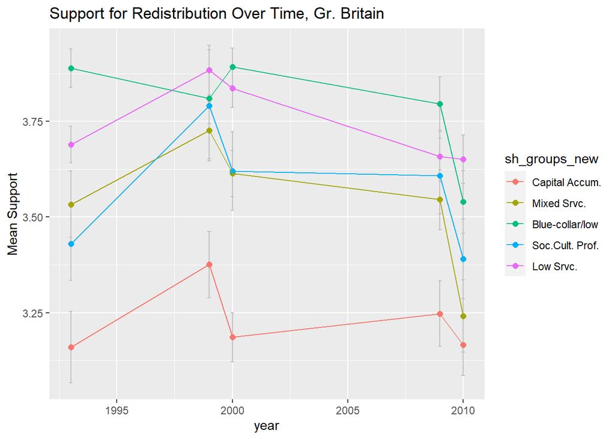

```r
fig2gb <- subset(fig2, cntry == 826)
fig2gb$sh_groups_new <- as.factor(fig2gb$sh_groups_new)

ggplot(fig2gb, aes(x=year, y=reduceM, color=sh_groups_new)) +
    geom_errorbar(aes(ymin=reduceM-reduceSE, ymax=reduceM+reduceSE), colour="grey", width = .15) +
    geom_point(size=2) +
    geom_line() +
    labs(title = "Support for Redistribution Over Time, Gr. Britain") +
    ylab(label = "Mean Support") +
    scale_color_hue(labels = c("Capital Accum.", "Mixed Srvc.", "Blue-collar/low", "Soc.Cult. Prof.", "Low Srvc."))
```

### Fig 4. United States

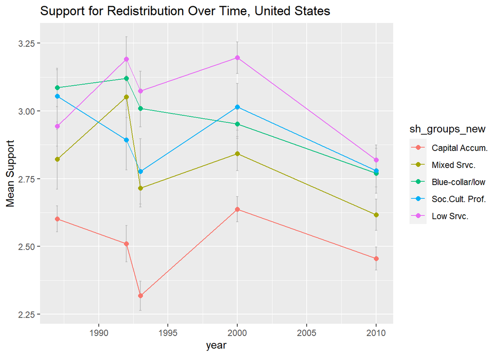

```r
fig2us <- subset(fig2, cntry == 840)
fig2us$sh_groups_new <- as.factor(fig2us$sh_groups_new)

ggplot(fig2us, aes(x=year, y=reduceM, color=sh_groups_new)) +
    geom_errorbar(aes(ymin=reduceM-reduceSE, ymax=reduceM+reduceSE), colour="grey", width = .15) +
    geom_point(size=2) +
    geom_line() +
    labs(title = "Support for Redistribution Over Time, United States") +
    ylab(label = "Mean Support") +
    scale_color_hue(labels = c("Capital Accum.", "Mixed Srvc.", "Blue-collar/low", "Soc.Cult. Prof.", "Low Srvc."))
```

## Different Approaches to Group Comparison

### 1. NHST - Null Hypothesis Significance Testing

We want to investigate if two groups are different. The null hypothesis is that they are not different. We have a linear model like such:

$Y_{gincdiff} = a_{intercept (reference-category)} + X_{1.poverty} + X_{2.blue-collar} + X_{4.others} + e$

The error term $e$ is the difference between the predicted values and the observed values in the data.

Here we look at the case of Germany 2010.

```r
de10 <- subset(df, year == 2010 & cntry == 276)

# remove all missing values for now

de10 <- subset(de10, !is.na(reduce))
de10$groups <- as.factor(de10$sh_groups_new)

# estimate means across groups ('lines-of-best-fit') - OLS

de10$groups <- relevel(de10$groups, ref = 3)

m1 <- lm(reduce ~ groups, data = de10)

summary(m1)
```

```
##
## Call:
## lm(formula = reduce ~ groups, data = de10)
##
## Residuals:
##     Min      1Q  Median      3Q     Max
## -2.8043 -0.7581  0.2419  1.1957  1.6336
##
## Coefficients:
##             Estimate Std. Error t value Pr(>|t|)
## (Intercept)  3.75811    0.04531  82.942  < 2e-16 ***
## groups1     -0.39170    0.06464  -6.060 1.58e-09 ***
## groups2     -0.19997    0.08172  -2.447   0.0145 *
## groups4     -0.12466    0.08370  -1.489   0.1365
## groups5      0.04618    0.07331   0.630   0.5288
## ---
## Signif. codes:  0 '***' 0.001 '**' 0.01 '*' 0.05 '.' 0.1 ' ' 1
##
## Residual standard error: 1.18 on 2329 degrees of freedom
##   (362 observations deleted due to missingness)
## Multiple R-squared:  0.02127,    Adjusted R-squared:  0.01959
## F-statistic: 12.65 on 4 and 2329 DF,  p-value: 3.461e-10
```

### Alternative Hypothesis Testing - Wald Tests

We can also compare the groups to a pre-specified value, like the sample mean. These are known as Likelihood Ratio and Wald tests

```r
# get sample mean

reduceM <- mean(de10$reduce)

# calculate test statistic, it will be the sample mean minus the intercept from m1

reduce_test <- reduceM - m1$coefficients[[1]]

# test that poverty group is sign different from sample mean
linearHypothesis(m1, c(paste0("groups2 =", reduce_test)))
```

|  | Res.Df | RSS | Df | Sum of Sq | F | Pr(>F) |
| --- | --- | --- | --- | --- | --- | --- |
| 1 | 2330 | 3242.478 | NA | NA | NA | NA |
| 2 | 2329 | 3241.822 | 1 | 0.6561421 | 0.4713877 | 0.4924178 |

```r
# test that both poverty and blue-collar group are significantly dif from sample mean
linearHypothesis(m1, c(paste0("groups1 =", reduce_test), paste0("groups2 =", reduce_test)))
```

|  | Res.Df | RSS | Df | Sum of Sq | F | Pr(>F) |
| --- | --- | --- | --- | --- | --- | --- |
| 1 | 2331 | 3263.343 | NA | NA | NA | NA |
| 2 | 2329 | 3241.822 | 2 | 21.52128 | 7.730695 | 0.0004505023 |

```r
# test that all three groups are different from sample mean
linearHypothesis(m1, c(paste0("groups1 =", reduceM), paste0("groups2 =", reduce_test), paste0("groups4 =", reduce_test)))
```

|  | Res.Df | RSS | Df | Sum of Sq | F | Pr(>F) |
| --- | --- | --- | --- | --- | --- | --- |
| 1 | 2332 | 10127.281 | NA | NA | NA | NA |
| 2 | 2329 | 3241.822 | 3 | 6885.459 | 1648.891 | 0 |